# **1 Molecular Descriptor**

## **1.1 Definition**

- Molecular descriptors are mathematical representations of a molecule derived through a specific algorithm applied to a defined molecular model or obtained from experimental measurements. [1]
- These numerical values describe a chemical structure by representing properties such as log P, molecular weight, hydrogen bond donors and acceptors, and rotatable bonds, which can be linked to experimental data about the molecule. [2]
- They serve as a way to quantify the structure and behavior of molecules to predict their properties, biological activity, or interaction with other substances.

## **1.2 Classification**

Descriptors can be classified by the following representations [1, 2, 3]:

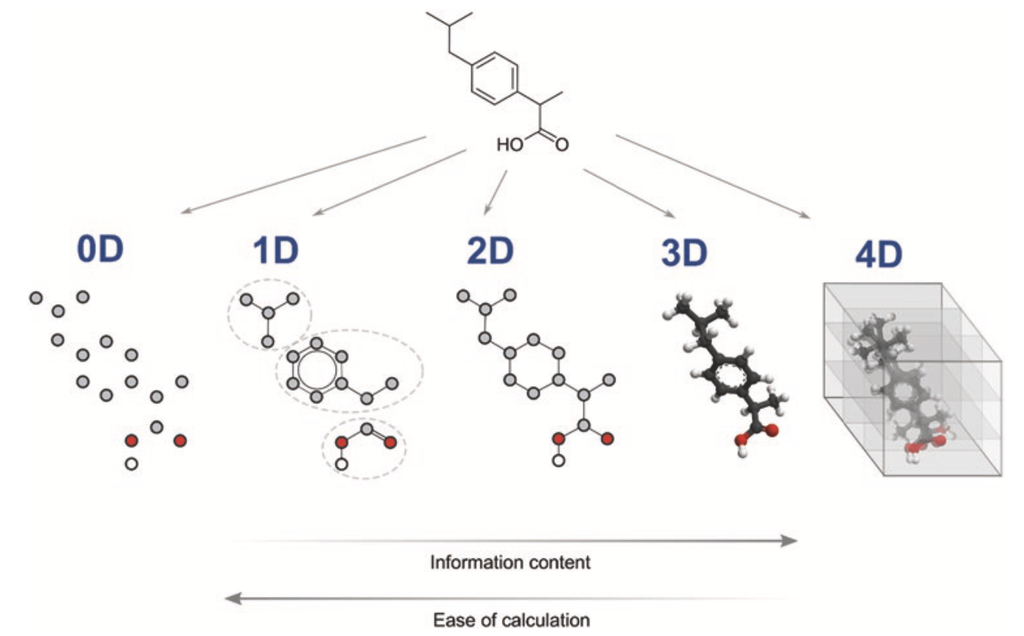

### **1.2.1 0D descriptors:**

0D descriptors are the simplest form of molecular representation, based solely on the chemical formula without considering their connectivity or bond types. These descriptors are often derived from simple counting or summarizing the overall composition of the molecule.

For example, the formula C₁₂H₄Cl₄O₂ for 2,3,7,8-Tetrachlorodibenzodioxin reveals the presence of 12 carbon, 4 hydrogen, 4 chlorine, and 2 oxygen atoms. These descriptors reflect bulk properties such as atom counts, molecular weight, or sums of atomic characteristics (e.g., van der Waals volumes).

Although easy to compute and interpret, 0D descriptors contain limited information and can yield the same values for different molecules, making them less specific.

### **1.2.2 1D descriptors:**

1D descriptors represent molecules as collections of substructures, such as functional groups or atom-centered fragment. These descriptors indicate whether specific substructures are present or absent (binary) or how frequently they occur within the molecule.

By focusing on molecular components, 1D descriptors provide a straightforward way to characterize molecules based on their functional features.

### **1.2.3 2D descriptors:**

2D descriptors build on 1D descriptors by incorporating information about how atoms are connected through chemical bonds, representing molecules as graphs where atoms are vertices and bonds are edges.

This allows for the calculation of topological indices (TIs), which encode topological properties (e.g., connectivity) and are sensitive to structural features like size, shape, branching, symmetry, and cyclicity. TIs can be divided into two categories: (1) topostructural indices, which focus on atom connectivity and distances, and (2) topochemical indices, which also account for atomic properties such as mass, polarizability, and the presence of functional groups.

By reflecting both structural and chemical characteristics, 2D descriptors provide deeper insights into molecular properties and behavior.

### **1.2.4 3D descriptors:**

3D descriptors provide a deeper level of molecular representation by capturing the spatial arrangement of atoms in three-dimensional space. This representation offers rich information that is valuable for modeling biological and pharmaceutical properties.

The accuracy of 3D descriptors depends on factors such as (1) the method used to optimize molecular geometry, (2) the existence of multiple low-energy conformations for flexible molecules, and (3) the potential difference between the computed structure and its bioactive form.

### **1.2.5 4D descriptors:**

4D descriptors extend molecular modeling by incorporating the dynamic interactions between molecules and biological receptors, aiming to quantify how molecules interact with active sites.

For example, molecules can be mapped onto a 3D grid where a probe (steric, electrostatic, or hydrophilic) scans their surface to capture interaction patterns.

# **2 Morgan Fingerprint**

## **2.1 Definition**

Morgan fingerprint, also known as the extended-connectivity fingerprint (ECFP), is one of the most commonly used hash fingerprints. In short, the Morgan fingerprint encodes the molecular features (such as atom groups) into binary vectors with length and radius as two parameters [4].

The Morgan fingerprint of a molecule can be easily generated by the RDKit package, and the atom group in each bit can also be obtained by using the package, which facilitates model interpretation. The Morgan fingerprint has been widely used in many QSAR models.

**Notes:**

- The length refers to the lengths of the vector, while the radius represents the size of the atom groups. The larger the radius, the larger the atom group it can represent.
- Each bit in the vector represents a unique or single atom group. However, if the vector’s length is too short, the same bit may represent two or several atom groups, resulting in bit collisions.

## **2.2 Principles**

The Morgan fingerprint is a type of molecular fingerprint, and it is based on the circular substructure of a molecule, capturing local atom environments within a fixed-radius neighborhood [5, 6].

**Notes:**

The radius of the Morgan fingerprint determines how far from each atom the fingerprint will consider. For example:

- Radius 1 (Diameter 2): Considers only the immediate neighbors of each atom (1 bond away).
- Radius 2 (Diameter 4): Considers neighbors of neighbors (2 bonds away), and so on.

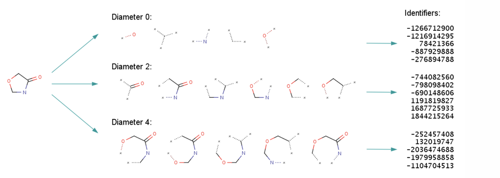

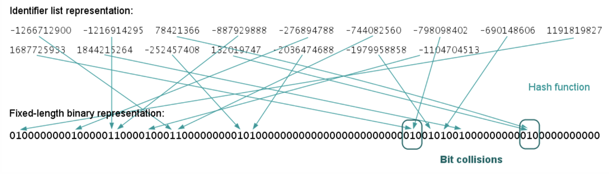

### **Step 1: Find the Circular Substructures**

- The fingerprint is constructed by considering neighborhoods of atoms in a molecule, starting from a specific atom and expanding outward in a circular fashion (hence the name "circular fingerprint").
- Each atom's local environment is defined by its neighbors, with the neighborhood size determined by the radius (often called the "radius of the fingerprint").

### **Step 2: Get Identifiers and Hash Values**

- Each atom is represented by a unique identifier based on the types of atoms in its neighborhood.
- A hashing function is applied to these identifiers, converting the atom’s local environment into a hash value.
- This hash value is then mapped into a position in a fixed-length bit vector (e.g., a binary array). If a substructure is present, the corresponding bit is set to 1; otherwise, it remains 0.

### **Step 3: Fixed-Length Output**

- After processing the entire molecule, the result is a fixed-length bit vector. The length of this vector depends on the hashing process and the number of bits used.
- Despite the size of the molecule is different, the Morgan fingerprint always outputs a vector of the same length, typically 1024 or 2048 bits.